# Testing Financial Strategies with R: Stock Picking

One of the most common financial advices that you can hear in every christmas meal is that you should be saving a fixed amount of money each month. Not only that, but you should avoid pre-cooked schemes offered by your bank and simply invest your savings in the stock market. Investing in the U.S. market or even the global stock market has been a wise decision if you look at the long term (more than 10 years), even if you invested in peak of any pre-crisis crest.

So it seems that saving some money and investing it in stocks looks like a good idea. Great. Now, which market should you invest in? Which stocks? A safer approach to that is just buying an ETF and follow the trend of some index. At the end you are putting your money in the general behaviour of the market. If the economy does well, you’ll do well. Otherwise, you could try to figure out which firms will exceed the market. In this article I will outline a way to test different strategies to base that decision on, using quantitative analysis of the financial statements.

Even though both claim to be quantitative, I need to stress the difference between what I will suggest and the famous *Technical Analysis* (TA). TA is built on historical price developments and believes that certain patterns on price history may be identified and used to predict future movements of the quotes. TA focuses on how investors’ behaviour might push prices in the future based on historical patterns.

In contrast with that, *Fundamental Analysis* (FA) focuses on the firm and the value of the ownership right itself, rather than on the market price of it. It established a defined difference between *Value* and *Price*. And it believes that the *Price* tends to reflect *Value* in the long term. Hence, it claims that the fair value can be computed from the future cash flows, debt, strategic position or future plans.

There is a huge and broad field on fundamental analysis that covers a lot of different perspectives of a firm; some of them quantitative and some others qualitative. One of the quantitative is the study of the financial statements of the firms.

Now, we’ll get down to business.

# Retrieving Data

In order to begin, we need data. We want to try out how we can compute the financial statements of firms to decide in which we should invest our savings. Therefore, we need those financial statements.

From now on, we will be making use of some R packages:

```r
library(tidyverse)
library(data.table)
library(quantmod)
library(rvest)
library(progress)
library(lubridate)
library(feather)
library(zoo)
```

Firstly, we need a list of the stock universe that we will be considering. For simplicity, I constructed this making use of the widest indexes of the *Standard & Poors*.

```r
getTickers <- function(){
    sp500_wiki <- read_html(
        "https://en.wikipedia.org/wiki/List_of_S%26P_500_companies")

    symbols_table <- sp500_wiki %>%
        html_nodes(xpath='//*[@id="mw-content-text"]/div/table[1]') %>%
        html_table()

    symbols_table <- symbols_table[[1]]
    tickers <- as.character(symbols_table$`Ticker symbol`)

    sp1000_wiki <- read_html(
        "https://en.wikipedia.org/wiki/List_of_S%26P_1000_companies")

    symbols_table <- sp1000_wiki %>%
        html_nodes(xpath='//*[@id="mw-content-text"]/div/table[3]') %>%
        html_table()

    symbols_table <- symbols_table[[1]]
    tickers2 <- as.character(symbols_table$`Ticker Symbol`)

    tickers <- c(tickers,tickers2)

    for(i in 1:length(tickers)) tickers[[i]] <- gsub('\\.', '-', tickers[[i]])

    return(tickers)
}
```

With this function `getTickers()` we’ve got a complete list of the tickers of 1500 companies, including 500 from the SP500. Now, we’ll use these stickers to get the financial statements from each one of the companies.

```r
getFinancials <- function(ticker){
    stock <- ticker
    output <- tibble()

    for (i in 1:length(stock)) {
        tryCatch(
            {
                url <- "https://finance.yahoo.com/quote/"
                url <- paste0(url,stock[i],"/financials?p=",stock[i])
                wahis.session <- html_session(url)
                p <-    wahis.session %>%
                    html_nodes(xpath = '//*[@id="Col1-1-Financials-Proxy"]/section/div[3]/table')%>%
                    html_table(fill = TRUE)
                IS <- p[[1]]
                colnames(IS) <- paste(IS[1,])
                IS <- IS[-c(1,5,12,20,25),]
                names_row <- paste(IS[,1])
                IS <- IS[,-1]
                IS <- apply(IS,2,function(x){gsub(",","",x)})
                IS <- as.data.frame(apply(IS,2,as.numeric))
                rownames(IS) <- paste(names_row)
                temp1 <- IS
                url <- "https://finance.yahoo.com/quote/"
                url <- paste0(url,stock[i],"/balance-sheet?p=",stock[i])
                wahis.session <- html_session(url)
                p <-    wahis.session %>%
                    html_nodes(xpath = '//*[@id="Col1-1-Financials-Proxy"]/section/div[3]/table')%>%
                    html_table(fill = TRUE)
                BS <- p[[1]]
                colnames(BS) <- BS[1,]
                BS <- BS[-c(1,2,17,28),]
                names_row <- BS[,1]
                BS <- BS[,-1]
                BS <- apply(BS,2,function(x){gsub(",","",x)})
                BS <- as.data.frame(apply(BS,2,as.numeric))
                rownames(BS) <- paste(names_row)
                temp2 <- BS
                url <- "https://finance.yahoo.com/quote/"
                url <- paste0(url,stock[i],"/cash-flow?p=",stock[i])
                wahis.session <- html_session(url)
                p <-    wahis.session %>%
                    html_nodes(xpath = '//*[@id="Col1-1-Financials-Proxy"]/section/div[3]/table')%>%
                    html_table(fill = TRUE)
                CF <- p[[1]]
                colnames(CF) <- CF[1,]
                CF <- CF[-c(1,3,11,16),]
                names_row <- CF[,1]
                CF <- CF[,-1]
                CF <- apply(CF,2,function(x){gsub(",","",x)})
                CF <- as.data.frame(apply(CF,2,as.numeric))
                rownames(CF) <- paste(names_row)
                temp3 <- CF
                #assign(paste0(stock[i],'.f'),value = list(IS = temp1,BS = temp2,CF = temp3),envir = parent.frame())
                total_df <- as.data.frame(rbind(temp1,temp2,temp3))
                total_df$value <- rownames(total_df)
                for(k in 1:length(total_df$value)) total_df$value[[k]] <- gsub(" ", "",total_df$value[[k]])
                financial_camps <- total_df$value
                df <- total_df %>% t()
                df <- df[!rownames(df) %in% c("value"),]
                dates <- rownames(df)
                df <- df %>% data.table()
                colnames(df) <- financial_camps
                df$date <- mdy(dates)
                df$firm <- stock[[i]]
            },
            error = function(cond){
                message(stock[i], "Give error ",cond)
            }
        )
        df[is.na(df)] <- 0
        output <- rbind(output, df)
    }
    return(output)
}
```

I know it looks messy, but it outputs all the financial statements available in Yahoo Finance for almost every ticker you input and it processes the data to yield it [tidy](https://vita.had.co.nz/papers/tidy-data.pdf).

Anagolously, we want to get the historical prices of each company.

```r
getPrices <- function(tickers, from = "1950-01-01"){
    stock_prices <- new.env()
    getSymbols(tickers, src = "yahoo", from = "1950-01-01", auto.assign = TRUE, env = stock_prices)

    all_prices <- tibble()

    for(i in 1:length(tickers)){
        raw_df <- stock_prices[[tickers[[i]]]][,6] %>% data.frame()
        dates <- raw_df %>% row.names() %>% as.Date()
        prices <- raw_df[,1]

        new_df <- data.frame(price = as.numeric(prices), date = dates) %>%
            data.table()

        new_df$firm <- tickers[[i]]

        all_prices <- rbind(all_prices,new_df)
    }
    return(all_prices)
}
```

Now we need to combine these two big sets. The financial data and the price history. The way I managed to put them together is not the most memory efficient, but it tries to avoid time-dependent biases. Let me show it.

```r
getMerge <- function(prices, financials){

    # Get common days
    k <- 1
    absences <- which(!(financials$date %in% prices$date))
    while(sum(!(unique(financials$date) %in% unique(prices$date))) > 0){
        count <- sum(!(unique(financials$date) %in% unique(prices$date)))
        financials$date[[absences[k]]] <- financials$date[[absences[k]]] + 1
        if(sum(!(unique(financials$date) %in% unique(prices$date))) < count) k <- k + 1
    }

    stocks <- unique(prices$firm)
    tidy_merged <- tibble()
    merged <- left_join(prices,financials, by = c("date", "firm"))
    for(s in stocks){
        df <- merged %>% filter(firm == s)
        tidy_merged <- df %>%
            na.locf() %>%
            na.omit() %>%
            distinct() %>%
            as_tibble() %>%
            rbind(tidy_merged)
    }

    tidy_merged$date <- as.Date(tidy_merged$date)
    tidy_merged$firm <- as.factor(tidy_merged$firm)
    cols <- colnames(tidy_merged)
    for(c in cols) if(is.character(tidy_merged[[c]])) tidy_merged[[c]] <- as.numeric(tidy_merged[[c]])

    tidy_merged <- tidy_merged %>%  distinct()

    return(tidy_merged)
}
```

The thing is that we want to simulate what a normal decision making would be. That means that you wake up today, run the code and can see the price closed tomorrow and the last financial statements published. And most of the time tomorrow the price would have changed but not the financial statements.

| price | date | firm | TotalRevenue | CostofRevenue | GrossProfit | ResearchDevelopment | SellingGeneralandAdministrative |
| --- | --- | --- | --- | --- | --- | --- | --- |
| 16.11 | 2015-06-01 | ANGO | 352392 | 180738 | 171654 | 26594 | 112382 |
| 16.08 | 2015-06-02 | ANGO | 352392 | 180738 | 171654 | 26594 | 112382 |
| 16.39 | 2015-06-03 | ANGO | 352392 | 180738 | 171654 | 26594 | 112382 |
| 16.07 | 2015-06-04 | ANGO | 352392 | 180738 | 171654 | 26594 | 112382 |
| 16.26 | 2015-06-05 | ANGO | 352392 | 180738 | 171654 | 26594 | 112382 |
| 16.1 | 2015-06-08 | ANGO | 352392 | 180738 | 171654 | 26594 | 112382 |

So this table gives you a glimpse of how the database looks like.

Now we have all custom functions that we need to retrieve and store all the data that we are going to need. As you might have supsected already, this is *a lot* of data. It blows up the RAM of my laptop and most certainly will do the same with yours. In order to avoid that I just decided to create a folder and save all the data in multiple files, so we’ll load one at a time when needed.

```r
tickers <- getTickers(index = "all")

pb <- progress_bar$new(total = length(tickers))

for(t in tickers){
    tryCatch({
        fins <- getFinancials(t)
        prices <- getPrices(t)
        whole_data <- getMerge(financials = fins, prices = prices)
        path <- paste0("data/",t)
        write_feather(whole_data,path)
    }, error=function(e){})

    pb$tick()
}
```

# Defining Investment Strategies

The broad investment strategy that I have defined for this test is the following: At the beginning of each month, an investor saves up some fixed amount of money and invests it in stocks. Which stocks will be decided based upon different more specific strategies that will be tested, but this is the general scheme.

```r
invest <- function(method, data, date, amount_to_invest = 1, stocks_owned, specificity = 1){
    d <- date
    stocks_available <- data %>%
                                            filter(date == d) %>%
                                            .$firm %>%
                                            unique() %>%
                                            as.character()
```

See that I have pasted a snippet of code that is an unclosed function. Is not a mistake, I will disclose the rest of the function very soon in many snippets for readability. Note that $specifitiy = 1$ and that it appears everywhere. I’ll explain that later.

## Benchmark: Random Selection

The more straightforwarad strategy that we could think of is the random selection. The investor just takes a random ticker from the list of available companies and invests all the money from this month into that stock. Simple as that.

This is going to serve as a benchmark. It is a quite dumb one, but any strategy that is not entirely useless musts outperform this strategy. What kind of financial strategy would be one that performs as well as blindly picking stocks out of the index?

```r
    if(method == "random"){
        selected_stock <- stocks_available %>%
        sample(specificity, replace = TRUE)
    }
```

## Price Earnings Ratio (PER)

Both praised and demonized, the PER is one of the most famous financial ratios that is studied in the stock market. This metric tells you how many years you should wait to recover your investment in case you would be getting paid the proportional revenue of the company.

$$PER = \frac{Price*CommonStock}{TotalRevenue}$$

It sounds kind of logic that the price of a stock should correlate with its capacitity of generating revenue. What it is a company if not a machine that inputs some money and outputs even more money? Therefore, it does not seem crazy to evaluate the *fair value* of a company based on its revenue. However, there is a lot of controversy on whether this ratio is useful or not for fundamental analysis. Amongst other things, some people claim that the revenue of a company is one of the metrics that can be more easily manipulated and hence we shouldn’t rely any decision based on them.

Considering all of that, I though it was worth testing it in our little experiment.

How will we do test it? Well, it is kind of common sense in investment environments to label companies as *expensive* if they have a high PER and as *cheap* if they have a low one. Following that logic, you should buy companies with lower PER, because they are cheaper. Therefore, each month in our experiment we will sort the stock universe by its present PER in ascending order and we will invest our monthly money into the top of the list. This way we will always invest in the cheapest companies available. No more considerations.

I know this is trategy is utterly simplistic and that we can not base all our fundamental-analysis-oriented stock picking in one single metric. But if this ratio holds some slight truth in its statements, it should be at least better than randomly choosing stocks. Otherwise this ratio is not giving us any useful information *whatsoever*.

```r
    if(method == "per"){
        selected_stock <- data %>%
            filter(date == d) %>%
            filter(firm %in% stocks_available) %>%
            mutate(per = price*CommonStock/TotalRevenue) %>%
            top_n(specificity, -per) %>%
            .$firm %>%
            unique() %>%
            as.character()
    }
```

## Enterprise Value over Earnings Before Intereses, Taxes, Depreciation and Amortization (EV/EBITDA)

The natural evolution of the PER is the EV/EBITDA, for *Enterprise Value over Earnings Before Intereses Taxes Depreciation and Amortization*. It kind of measures the same thing but in a smarter more sophisticated way. It avoids using the revenue metrics - as they are less reliable - and it takes into account more metrics to compute the Enterprise Value than simply the Price. The formula would be like this:

$$EV/EBITDA = \frac{Price*CommonStock + PreferredStock + MinorityInterest + LongTermDebt - CashAndCashEquivalents}{EarningsBeforeInterestandTaxes}$$

Lately, it has become the new preference for simplistic fundamental analysis in order to label companies as “cheap” or “expensive”.

Analogously to the PER, in this strategy we will sort the list of companies based on their present EV/EBITDA in ascending order, using the latest financial statements and “*today’s*” price, at the beginning of each month. Then we just pick the top of the list as our chosen stock for this month’s investment.

```r
        selected_stock <- data %>%
            filter(date == d) %>%
            filter(firm %in% stocks_available) %>%
            mutate(evebitda = (EarningsBeforeInterestandTaxes)/(price*CommonStock + PreferredStock + MinorityInterest + LongTermDebt - CashAndCashEquivalents)) %>%
            top_n(specificity, evebitda) %>%
            .$firm %>%
            unique() %>%
            as.character()
```

## Dividends Paid over Enterprise Value

This strategy diverges a bit from the philosophy of the other two. It is the conclusion of framing the expected returns from the investments as what you get paid from being the owner of a stock (dividents) instead of the return that you can get if you sell your stocks in the future. I’m not saying that this strategy won’t compute the increase in the owned stocks as a profit, but that the decision making of picking the stock is based more on that expectetions of the dividends and less in trying to forecast the future price of the stock. Is another way of stating that, acknowledging that I won’t see the Earnings of the company, the only earnings that I consider are the revenues that the company directly yields me. i.e. the *Dividends*.

and simply say that the larger this number is, the better. Therefore, we do the same as always, we compute this number at the beginning of each and every month, we sort the list of companies based on this number in dreceasing order and we pick the top of the list.

```r
    if(method == "dividends_ev"){
        selected_stock <- data %>%
            filter(date == d) %>%
            filter(firm %in% stocks_available) %>%
            mutate(dividends_ev = (DividendsPaid)/(price*CommonStock + PreferredStock + MinorityInterest + LongTermDebt - CashAndCashEquivalents)) %>%
            top_n(specificity, dividends_ev) %>%
            .$firm %>%
            unique() %>%
            as.character()
    }
```

## Combined Dividends and EBITDA

Since we’ve got explained some quite convincing ideas, I thought that would be interesting to put them together in one combined strategy that I call *Dividends and Revenues*, for lack of a better name.

The formula would be the following:

$$\frac{EarningsBeforeInterestandTaxes*DividendsPaid}{Price*CommonStock + PreferredStock + MinorityInterest + LongTermDebt - CashAndCashEquivalents}$$

Note that since we’ll decide based on a ranking, this combined metric does not depend so much on scale, and it takes into account both Dividends and Revenues equally.

```r
    if(method == "div_and_rev"){
        selected_stock <- data %>%
            filter(date == d) %>%
            filter(firm %in% stocks_available) %>%
            mutate(div_and_rev = (EarningsBeforeInterestandTaxes)*(DividendsPaid)/(price*CommonStock + PreferredStock + MinorityInterest + LongTermDebt - CashAndCashEquivalents)) %>%
            top_n(specificity, div_and_rev) %>%
            .$firm %>%
            unique() %>%
            as.character()
    }
```

# Investment Simulation

I warn you that this section is really messy, I’ll just paste huge bunches of code that are not so easy to read because I’ve prioritized memory efficiency and speed. So be patient or skip it and go directly to the explanation below each one

Now that you are warned, here we go:

```r
simulate_multiple_strategies <- function(data, amount_to_invest = 1, specificity = 1, strategies){

    count_strategy <- 0

    history_value <- c()
    history_strategies <- c()
    history_dates <- c()

    dates <- unique(data$date) %>% sort()
    dates_array <- data$date
    prices_array <- data$price
    firms_array <- data$firm
    portfolio <- tibble()
    stocks_owned <- list()

    pb <- progress_bar$new(
        format = "(:spin) [:bar] :percent     eta: :eta",
        total = length(dates), clear = FALSE, width = 60)

    for(s in strategies) stocks_owned[[s]] <- list()

    for(i in 1:length(dates)){
        pb$tick()
        d <- dates[[i]]

        pos_date <- which(dates_array == d)

        today_price <- prices_array[pos_date] %>% as.numeric()
        today_firm <- firms_array[pos_date] %>% as.character()

        for(strategy in (strategies)){

            # Invest first day of each month
            if(!(class(try(dates[[i-1]], silent = TRUE)) == 'try-error')){
                if(day(dates[[i]]) < day(dates[[i-1]])){
                    stocks_owned[[strategy]] <- invest(method = strategy, data = data, date = d, amount_to_invest = amount_to_invest, stocks_owned = stocks_owned[[strategy]], specificity = specificity)
                }
            }else{
                stocks_owned[[strategy]] <- invest(method = strategy, data = data, date = d, amount_to_invest = amount_to_invest, stocks_owned = stocks_owned[[strategy]], specificity = specificity)
            }

            # Compute Portfolio value
            tmp_value <- 0
            tmp_benchmark <- 0

            stocks <- names(stocks_owned[[strategy]])
            for(n in 1:length(stocks)){
                st <- stocks[[n]]
                pos_firm <- which(firms_array == st)
                today_price <- prices_array[intersect(pos_date, pos_firm)]
                tmp_value <- tmp_value + sum(stocks_owned[[strategy]][[st]]*today_price)
            }

        history_value[[i + count_strategy]] <- tmp_value
        history_strategies[[i + count_strategy]] <- strategy
        history_dates[[i + count_strategy]] <- d
        count_strategy <- count_strategy + 1
        }
    }
    results <- data.table(value = history_value,
                                        strategy = history_strategies,
                                        date = as.Date(history_dates)) %>%
        na.omit()

    return(list(results = results, portfolio = stocks_owned))
}
```

Long story short, this code implements many strategies and stores the value of their simulated portfolios in a daily basis. This way we’ve got the whole daily time evolution of the value of each strategy from the beginning.

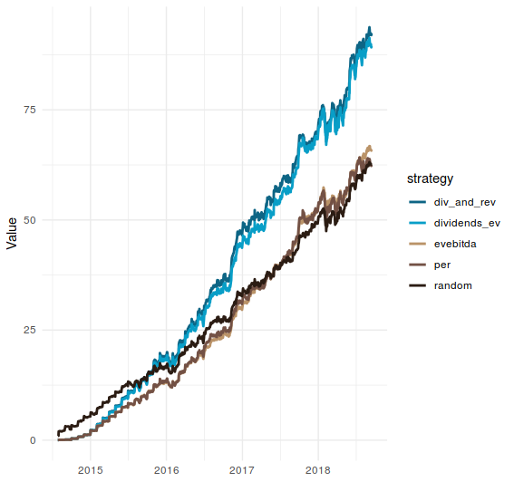

Since we want to rely in the lack of bias of randomness, we need to iterate this process a lot of times. As many as you can.